# Building a predictive model to estimate the total price (realSum) of a room based on its features.

importing necessary libraries

```python
import pandas as pd
import numpy as np
```

```python
hr=pd.read_csv('amsterdam_weekdays.csv')
hr.head()
```

|  | Unnamed: 0 | realSum | room_type | room_shared | room_private | person_capacity | host_is_superhost | multi | biz | cleanliness_rating | guest_satisfaction_overall | bedrooms | dist | metro_dist | attr_index | attr_index_norm | rest_index | rest_index_norm | lng | lat |
| --- | --- | --- | --- | --- | --- | --- | --- | --- | --- | --- | --- | --- | --- | --- | --- | --- | --- | --- | --- | --- |
| 0 | 0 | 194.033698 | Private room | False | True | 2.0 | False | 1 | 0 | 10.0 | 93.0 | 1 | 5.022964 | 2.539380 | 78.690379 | 4.166708 | 98.253896 | 6.846473 | 4.90569 | 52.41772 |
| 1 | 1 | 344.245776 | Private room | False | True | 4.0 | False | 0 | 0 | 8.0 | 85.0 | 1 | 0.488389 | 0.239404 | 631.176378 | 33.421209 | 837.280757 | 58.342928 | 4.90005 | 52.37432 |
| 2 | 2 | 264.101422 | Private room | False | True | 2.0 | False | 0 | 1 | 9.0 | 87.0 | 1 | 5.748312 | 3.651621 | 75.275877 | 3.985908 | 95.386955 | 6.646700 | 4.97512 | 52.36103 |
| 3 | 3 | 433.529398 | Private room | False | True | 4.0 | False | 0 | 1 | 9.0 | 90.0 | 2 | 0.384862 | 0.439876 | 493.272534 | 26.119108 | 875.033098 | 60.973565 | 4.89417 | 52.37663 |
| 4 | 4 | 485.552926 | Private room | False | True | 2.0 | True | 0 | 0 | 10.0 | 98.0 | 1 | 0.544738 | 0.318693 | 552.830324 | 29.272733 | 815.305740 | 56.811677 | 4.90051 | 52.37508 |

```python
pd.crosstab(hr["person_capacity"],hr["cleanliness_rating"])
```

| cleanliness_rating person_capacity | 4.0 | 5.0 | 6.0 | 7.0 | 8.0 | 9.0 | 10.0 |
| --- | --- | --- | --- | --- | --- | --- | --- |
| 2.0 | 2 | 0 | 5 | 8 | 42 | 179 | 420 |
| 3.0 | 0 | 0 | 1 | 1 | 7 | 23 | 47 |
| 4.0 | 0 | 1 | 3 | 2 | 36 | 120 | 171 |
| 5.0 | 0 | 0 | 0 | 0 | 2 | 3 | 6 |
| 6.0 | 0 | 0 | 0 | 0 | 0 | 9 | 15 |

```python
hr.drop(['attr_index', 'attr_index_norm', 'rest_index',
       'rest_index_norm', 'lng', 'lat'],axis=1,inplace=True)
```

Let's check if we have any null values and drop them for model consistency and accuracy.

```python
hr.isnull().sum()
```

```
Unnamed: 0                    0
realSum                       0
room_type                     0
room_shared                   0
room_private                  0
person_capacity               0
host_is_superhost             0
multi                         0
biz                           0
cleanliness_rating            0
guest_satisfaction_overall    0
bedrooms                      0
dist                          0
metro_dist                    0
dtype: int64
```

It looks like there are no null values!

```
<function matplotlib.pyplot.show(close=None, block=None)>
```

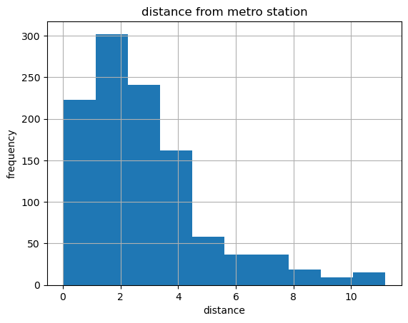

```python
#histogram
import seaborn as sns
import matplotlib.pyplot as plt
hr.hist('dist')
plt.xlabel('distance')
plt.ylabel('frequency')
plt.title('distance from metro station')
plt.show
```

this histogram shows a right skewed distribution and it will be a problem for model building as most models work with normal distribution. what do we do? lets make it a normal distribution for proper modelfitting and model stability.

```
<function matplotlib.pyplot.show(close=None, block=None)>
```

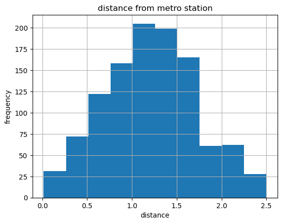

```python
hr['log_tranformation']=np.log1p(hr['dist'])
hr.hist('log_tranformation')
plt.xlabel('distance')
plt.ylabel('frequency')
plt.title('distance from metro station')
plt.show
```

```
<function matplotlib.pyplot.show(close=None, block=None)>
```

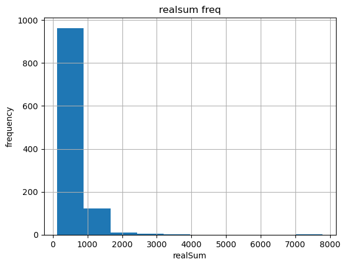

```python
hr.hist('realSum')
plt.xlabel('realSum')
plt.ylabel('frequency')
plt.title('realsum freq')
plt.show
```

```
<function matplotlib.pyplot.show(close=None, block=None)>
```

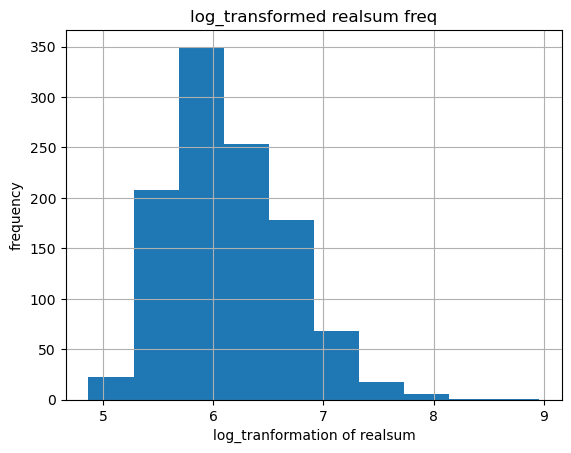

```python
hr['log_tranformation of realsum']=np.log1p(hr['realSum'])
hr.hist('log_tranformation of realsum')
plt.xlabel('log_tranformation of realsum')
plt.ylabel('frequency')
plt.title('log_transformed realsum freq')
plt.show
```

now it looks good for our model :)

```python
print(hr.columns)
```

```
Index(['Unnamed: 0', 'realSum', 'room_type', 'room_shared', 'room_private',
       'person_capacity', 'host_is_superhost', 'multi', 'biz',
       'cleanliness_rating', 'guest_satisfaction_overall', 'bedrooms', 'dist',
       'metro_dist', 'log_tranformation', 'log_tranformation of realsum'],
      dtype='object')
```

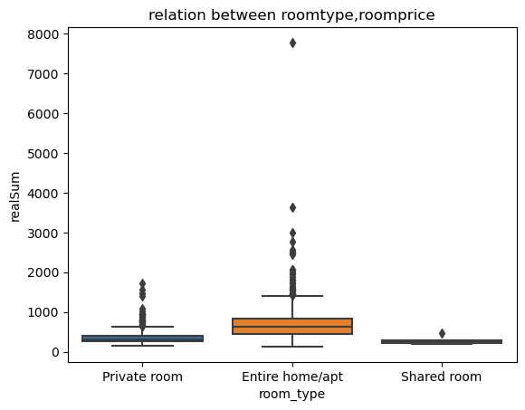

```python
# Box plot(one categorical and one continous varaible)
sns.boxplot(x='room_type',y='realSum',data=hr)
plt.title('relation between roomtype,roomprice')
plt.show()
```

Entire home/apartment has the highest median price, followed by Private rooms, with Shared rooms being the most affordable option. The presence of outliers, particularly in the Private room and Entire home/apartment categories, suggests that some properties might be significantly more expensive due to unique features or locations.

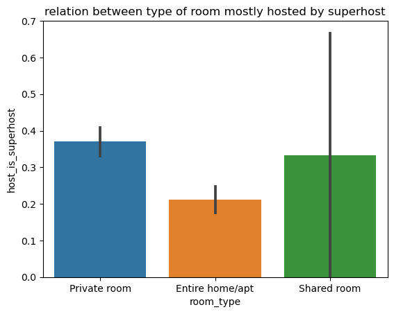

```python
sns.barplot(x='room_type',y='host_is_superhost',data=hr)
plt.title('relation between type of room mostly hosted by superhost')
plt.show()
```

Private rooms and shared rooms have a higher likelihood of being hosted by superhosts compared to entire homes/apartments. Entire homes/apartments are the least likely to be hosted by superhosts, which could suggest different hosting strategies or market dynamics for this room type. The wider error bar for shared rooms indicates more uncertainty in the estimate, likely because fewer shared room listings are available in the dataset. This relationship could be helpful for understanding how room type might correlate with quality (as indicated by the superhost status) when building models for prediction or recommendation systems.

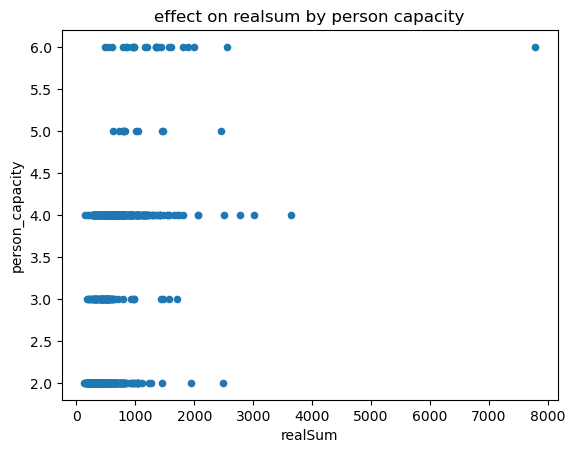

```python
import matplotlib.pyplot as plt
import seaborn as sns
hr.plot.scatter(x='realSum',y='person_capacity')
plt.title('effect on realsum by person capacity')
plt.show()
```

I'll be using encoding methods for handling categorical data(ex:strings,float,labels) cannot be directly used in calculations. we are transforming it into numerical format.

```python
from sklearn.preprocessing import OneHotEncoder
encoder=OneHotEncoder(sparse_output=False)
onehotencoding=encoder.fit_transform(hr[['room_type','room_shared','host_is_superhost','room_private']])
onehotencoding
```

```
array([[0., 1., 0., ..., 0., 0., 1.],
       [0., 1., 0., ..., 0., 0., 1.],
       [0., 1., 0., ..., 0., 0., 1.],
       ...,
       [0., 1., 0., ..., 0., 0., 1.],
       [1., 0., 0., ..., 0., 1., 0.],
       [0., 0., 1., ..., 0., 1., 0.]])
```

```python
newcol=encoder.getfeaturenamesout(['room_type','room_shared','host_is_superhost','room_private'])
#I'm now making a dataframe
newdf=pd.DataFrame(onehotencoding,columns=newcol)
newdf.head()
```

[output not shown]

Now we have successfully made the categorical variables into continous variables for our linear regression model or other models and we need to add the columns to the dataframe to make use of it furthur. since we dont need the old columns with categorical varaibles we can now drop and check for any missing values present for our model building.

```python
hr.drop(['room_type','room_shared','host_is_superhost','room_private',],axis=1,inplace=True)
```

```python
hr.head()
```

```
   Unnamed: 0     realSum  person_capacity  multi  biz  cleanliness_rating  \
0           0  194.033698              2.0      1    0                10.0
1           1  344.245776              4.0      0    0                 8.0
2           2  264.101422              2.0      0    1                 9.0
3           3  433.529398              4.0      0    1                 9.0
4           4  485.552926              2.0      0    0                10.0

   guest_satisfaction_overall  bedrooms      dist  metro_dist  \
0                        93.0         1  5.022964    2.539380
1                        85.0         1  0.488389    0.239404
2                        87.0         1  5.748312    3.651621
3                        90.0         2  0.384862    0.439876
4                        98.0         1  0.544738    0.318693

   log_tranformation  log_tranformation of realsum
0           1.795579                      5.273172
1           0.397695                      5.844257
2           1.909292                      5.580112
3           0.325601                      6.074264
4           0.434854                      6.187346
```

```python
mldata=pd.concat([hr,newdf],axis=1)
mldata
```

```
      Unnamed: 0      realSum  person_capacity  multi  biz  \
0              0   194.033698              2.0      1    0
1              1   344.245776              4.0      0    0
2              2   264.101422              2.0      0    1
3              3   433.529398              4.0      0    1
4              4   485.552926              2.0      0    0
...          ...          ...              ...    ...  ...
1098        1098  2486.115342              2.0      0    0
1099        1099   233.637194              2.0      1    0
1100        1100   317.062311              2.0      1    0
1101        1101  1812.855904              4.0      0    0
1102        1102   258.008577              2.0      0    0

      cleanliness_rating  guest_satisfaction_overall  bedrooms      dist  \
0                   10.0                        93.0         1  5.022964
```

[output cut: 77 more lines]

```python
#checking for missing values
mldata.isnull().sum()
```

```
Unnamed: 0                      0
realSum                         0
person_capacity                 0
multi                           0
biz                             0
cleanliness_rating              0
guest_satisfaction_overall      0
bedrooms                        0
dist                            0
metro_dist                      0
log_tranformation               0
log_tranformation of realsum    0
room_type_Entire home/apt       0
room_type_Private room          0
room_type_Shared room           0
room_shared_False               0
room_shared_True                0
host_is_superhost_False         0
host_is_superhost_True          0
room_private_False              0
room_private_True               0
dtype: int64
```

```python
# Assuming mldata is  filtered dataset with no outliers:-
X = mldata[['person_capacity','multi','biz','cleanliness_rating',
                        'guest_satisfaction_overall','bedrooms','metro_dist',
                        'log_tranformation','room_type_Entire home/apt',
                        'room_type_Private room','room_type_Shared room',
                        'room_shared_False','room_shared_True',
                        'host_is_superhost_False','host_is_superhost_True',
                        'room_private_False','room_private_True']]

# Update y to use only the non-outlier rows
y = mldata['log_tranformation of realsum']
```

so now i will be using feature selection to reduce the dimensionality of the input data to avoid overfitting and improve model's generalisation.

```python
from sklearn.feature_selection import RFE
from sklearn.linear_model import LinearRegression
model=LinearRegression()
rfe=RFE(model,n_features_to_select=3)
fit=rfe.fit(X,y)


featureranking =pd.DataFrame({
    'Feature': X.columns,
    'Ranking': fit.ranking_
})

featureranking
```

|  | Feature | Ranking |
| --- | --- | --- |
| 0 | person_capacity | 9 |
| 1 | multi | 12 |
| 2 | biz | 11 |
| 3 | cleanliness_rating | 14 |
| 4 | guest_satisfaction_overall | 15 |
| 5 | bedrooms | 10 |
| 6 | metro_dist | 13 |
| 7 | log_tranformation | 8 |
| 8 | room_type_Entire home/apt | 1 |
| 9 | room_type_Private room | 2 |
| 10 | room_type_Shared room | 4 |
| 11 | room_shared_False | 5 |
| 12 | room_shared_True | 3 |
| 13 | host_is_superhost_False | 7 |
| 14 | host_is_superhost_True | 6 |
| 15 | room_private_False | 1 |
| 16 | room_private_True | 1 |

```python
top_features = featureranking[featureranking['Ranking'] == 1]['Feature']
X_top = mldata[top_features]
```

Ill be using z score approach to ensure that machine learning models are trained on data that more accurately represents the underlying patterns, improving the reliability of the predictions made by those models.

```python
from scipy import stats

columns = ['person_capacity', 'multi', 'biz', 'cleanliness_rating',
           'guest_satisfaction_overall', 'bedrooms','metro_dist',
           'log_tranformation', 'room_type_Entire home/apt', 'room_type_Private room',
           'room_type_Shared room', 'room_shared_False', 'room_shared_True',
           'host_is_superhost_False', 'host_is_superhost_True',
           'room_private_False', 'room_private_True']
z_scores = np.abs(stats.zscore(mldata[columns]))
# Set a Z-score threshold (e.g., 3.0)
threshold = 3

# Identify rows where Z-score is less than the threshold (i.e., no outliers)
mldata_no_outliers = mldata[(z_scores < threshold).all(axis=1)]

# Check the shape of the new dataset
print("Original dataset shape:", mldata.shape)
print("Dataset shape after outlier removal:", mldata_no_outliers.shape)
```

```
Original dataset shape: (1103, 21)
Dataset shape after outlier removal: (1016, 21)
```

```python
from sklearn.model_selection import train_test_split
from sklearn.linear_model import LinearRegression
from sklearn.metrics import mean_squared_error, r2_score

# Train-test split
X_train, X_test, y_train, y_test = train_test_split(X, y, test_size=0.3, random_state=42)

# Model training
model = LinearRegression()
model.fit(X_train, y_train)

# Evaluation
y_pred_train = model.predict(X_train)
y_pred_test = model.predict(X_test)

# RMSE and R-squared calculation
train_rmse = mean_squared_error(y_train, y_pred_train, squared=False)
test_rmse = mean_squared_error(y_test, y_pred_test, squared=False)
train_r2 = r2_score(y_train, y_pred_train)
test_r2 = r2_score(y_test, y_pred_test)

print("RMSE (Train):", train_rmse)
print("RMSE (Test):", test_rmse)
print("R-squared (Train):", train_r2)
print("R-squared (Test):", test_r2)
```

```
RMSE (Train): 0.2980324876519899
RMSE (Test): 0.3056515831592978
R-squared (Train): 0.7035884810588385
R-squared (Test): 0.6439048324041238
```

Linear regression model demonstrates a reasonable ability to predict the target variable, explaining over 70% of the variance in the training set and about 64% in the test set. The RMSE values indicate that the average prediction error is fairly low, suggesting that your model is performing adequately The small difference between training and test RMSE suggests that while the model is relatively stable, there may still be some room for improvement in terms of generalization to unseen data.

```python
from sklearn.metrics import mean_squared_error, r2_score
from sklearn.ensemble import RandomForestRegressor
from sklearn.model_selection import train_test_split
# Define X and y from the cleaned dataset
X = mldata[['person_capacity','multi','biz','cleanliness_rating','guest_satisfaction_overall','bedrooms','metro_dist','log_tranformation','room_type_Entire home/apt','room_type_Private room','room_type_Shared room','room_shared_False','room_shared_True','host_is_superhost_False','host_is_superhost_True','room_private_False','room_private_True']]
y = mldata['log_tranformation of realsum']

# Split the cleaned data
X_train, X_test, y_train, y_test = train_test_split(X, y, test_size=0.3, random_state=42)

# Retrain the Random Forest model
rf= RandomForestRegressor(n_estimators=200, max_depth=5, random_state=42)
rf.fit(X_train, y_train)

# Make predictions
y_pred_train_rf= rf.predict(X_train)
y_pred_test_rf = rf.predict(X_test)

# Evaluate the model
rmse_train_rf = mean_squared_error(y_train, y_pred_train_rf, squared=False)
rmse_test_rf = mean_squared_error(y_test, y_pred_test_rf, squared=False)

r2_train_rf = r2_score(y_train, y_pred_train_rf)
r2_test_rf= r2_score(y_test, y_pred_test_rf)

# Print the results
print(f'Random Forest RMSE (Train) {rmse_train_rf}')
print(f'Random Forest RMSE (Test)  {rmse_test_rf}')
print(f'Random Forest R-squared (Train) {r2_train_rf}')
print(f'Random Forest R-squared (Test)  {r2_test_rf}')
```

```
Random Forest RMSE (Train) 0.2478640458726353
Random Forest RMSE (Test)  0.31184892122000524
Random Forest R-squared (Train) 0.7949806133126841
Random Forest R-squared (Test)  0.6293181917266377
```

The Root Mean Squared Error (RMSE) for the training dataset is approximately 0.248.A lower RMSE value suggests that the model fits the training data well, meaning it has learned the relationships in the training dataset effectively. The RMSE for the test dataset is approximately 0.312. This value is slightly higher than the training RMSE, indicating that the model's predictions on unseen data (test set) are somewhat less accurate compared to the training data. The R-squared value for the training set is approximately 0.795.About 79.5% of the variance in the target variable can be explained by the features used in the model for the training dataset. The R-squared value for the test set is approximately 0.629.About 62.9% of the variance in the target variable can be explained by the features used in the model for the test dataset.It indicates that the model may not generalize as well to unseen data compared to its performance on the training data. The model shows good performance on the training data with a relatively low RMSE and high R-squared, indicating that it has captured the underlying patterns effectively. However, the slightly higher RMSE and lower R-squared on the test set suggest some degree of overfitting, where the model performs significantly better on the training data than on unseen data.

```python
from sklearn.model_selection import cross_val_score

# Perform 5-fold cross-validation on the Random Forest model
cv_scores = cross_val_score(rf, X_train, y_train, cv=5, scoring='neg_mean_squared_error')
avg_rmse = np.mean(np.sqrt(-cv_scores))

print("Average RMSE from cross-validation:", avg_rmse)
```

```
Average RMSE from cross-validation: 0.30590249098144306
```

An average RMSE from cross-validation that aligns closely with the test RMSE reinforces that model is both accurate and stable, performing similarly across different data subsets. This reinforces that the model is reliable for new, unseen data.

I'm using K-Fold Cross-Validation to assess how well the model performs on different subsets of the data, giving a more robust evaluation than a single train-test split. This approach is particularly useful for detecting overfitting or underfitting and helps validate that the model’s performance isn’t due to a specific data split.

```python
import numpy as np
import pandas as pd
from sklearn.model_selection import train_test_split, KFold, cross_val_score
from sklearn.linear_model import LinearRegression
from sklearn.metrics import mean_squared_error, r2_score

# Assuming mldata_no_outliers is already defined and preprocessed
X = mldata_no_outliers[['person_capacity', 'multi', 'biz', 'cleanliness_rating',
                         'guest_satisfaction_overall', 'bedrooms', 'metro_dist',
                         'log_tranformation', 'room_type_Entire home/apt',
                         'room_type_Private room', 'room_type_Shared room',
                         'room_shared_False', 'room_shared_True',
                         'host_is_superhost_False', 'host_is_superhost_True',
                         'room_private_False', 'room_private_True']]
y = mldata_no_outliers['log_tranformation of realsum']

# Initialize the linear regression model
lr = LinearRegression()

# Set up K-Folds
k = 5  # You can change this value based on your needs
kf = KFold(n_splits=k, shuffle=True, random_state=42)

# List to store RMSE and R-squared for each fold
rmse_scores = []
r2_scores = []

# Perform cross-validation
for train_index, test_index in kf.split(X):
    X_train, X_test = X.iloc[train_index], X.iloc[test_index]
    y_train, y_test = y.iloc[train_index], y.iloc[test_index]

    # Fit the model to the training data
    lr.fit(X_train, y_train)

    # Make predictions on the test set
    y_test_pred = lr.predict(X_test)

    # Calculate RMSE for the test set
    fold_rmse = np.sqrt(mean_squared_error(y_test, y_test_pred))
    rmse_scores.append(fold_rmse)

    # Calculate R-squared for the test set
    fold_r2 = r2_score(y_test, y_test_pred)
    r2_scores.append(fold_r2)

# Print the results
print("K-Fold RMSE Scores:", rmse_scores)
print("Average RMSE:", np.mean(rmse_scores))
print("K-Fold R-squared Scores:", r2_scores)
print("Average R-squared:", np.mean(r2_scores))
```

```
K-Fold RMSE Scores: [0.29875158712631183, 0.28574265212547184, 0.2604278121836095, 0.3197268431064835, 0.3086245994586398]
Average RMSE: 0.2946546988001033
K-Fold R-squared Scores: [0.6356265188332595, 0.7233193282261168, 0.6630592768972128, 0.6502551528418101, 0.5957488071024758]
Average R-squared: 0.6536018167801749
```

The similarity in RMSE and R-squared scores across folds points to a stable model with consistent performance, regardless of data split. This stability suggests that the model generalizes well to different data subsets.